# Tugas Kuliah K3 (ARDL)

## 6.4 Uji ADF

### 6.4.1 Uji ADF DTMA

```r
adf.test(DTMA)
```

```
##
##  Augmented Dickey-Fuller Test
##
## data:  DTMA
## Dickey-Fuller = -12.518, Lag order = 9, p-value = 0.01
## alternative hypothesis: stationary
```

- TMA stasioner secara uji formal

### 6.4.2 Uji ADF DPC

```r
adf.test(DPC)
```

```
##
##  Augmented Dickey-Fuller Test
##
## data:  DPC
## Dickey-Fuller = -14.984, Lag order = 9, p-value = 0.01
## alternative hypothesis: stationary
```

- PC stasioner secara uji formal

### 6.4.3 Uji ADF DRH

```r
adf.test(DRH)
```

```
##
##  Augmented Dickey-Fuller Test
##
## data:  DRH
## Dickey-Fuller = -13.91, Lag order = 9, p-value = 0.01
## alternative hypothesis: stationary
```

- RH stasioner secara uji formal

## 6.5 **Plot CCF (Lag optimum peubah penjelas)**

### 6.5.1 Plot CCF DTMA dan DPC

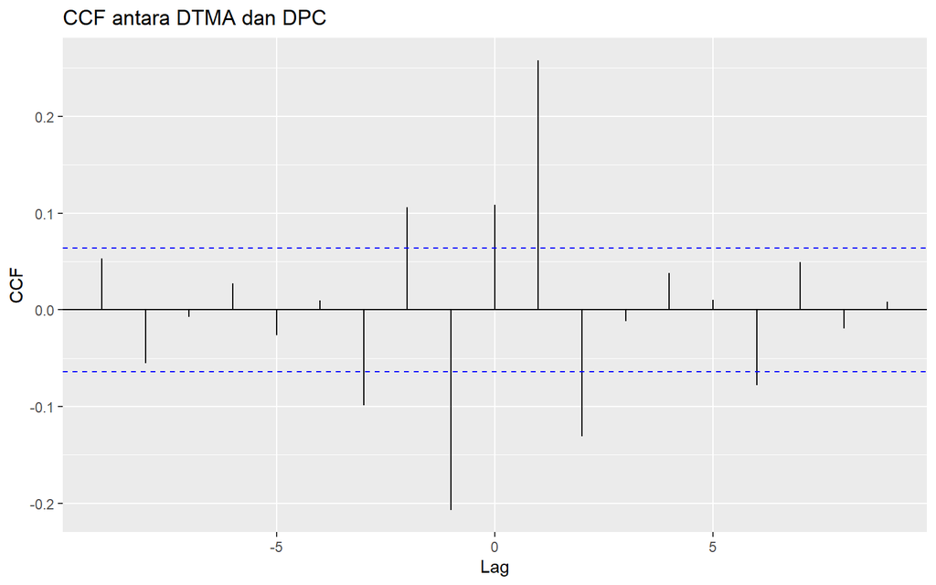

```r
ccf_result1 <- ggCcf(DTMA, DPC, lag.max=9)+ggtitle("CCF antara DTMA dan DPC")
ccf_result1
```

- Lag optimum q1 = 1

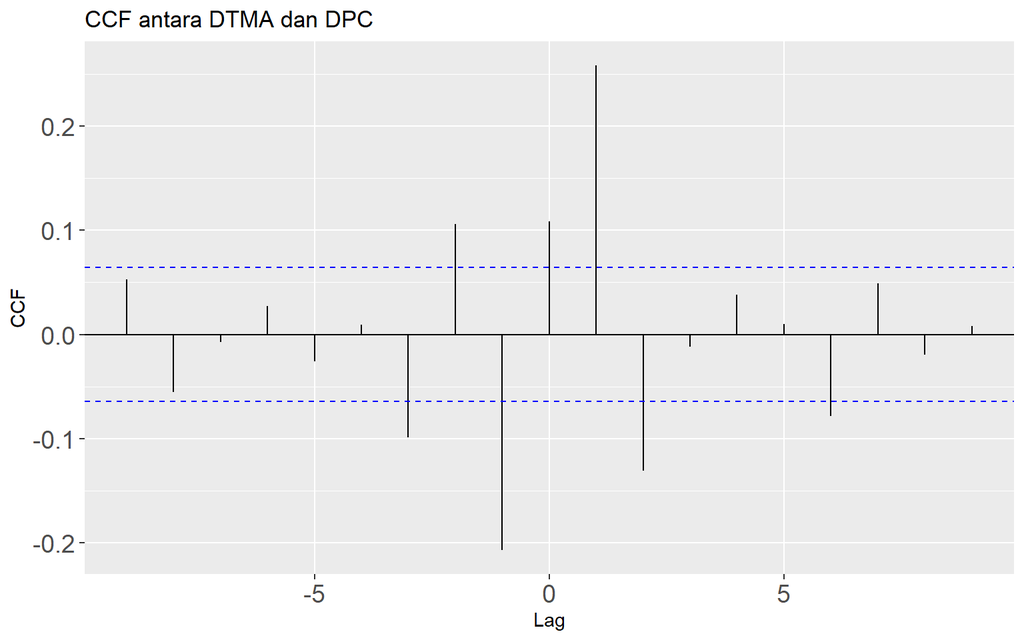

```r
ccf_result1 <- ggCcf(DTMA, DPC, lag.max = 9) +
  ggtitle("CCF antara DTMA dan DPC") +
  theme(
    axis.text.x = element_text(size = 14),  # Besarkan angka di sumbu X
    axis.text.y = element_text(size = 14)   # Besarkan angka di sumbu Y
  )
ccf_result1
```

### 6.5.2 Plot CCF DTMA dan DRH

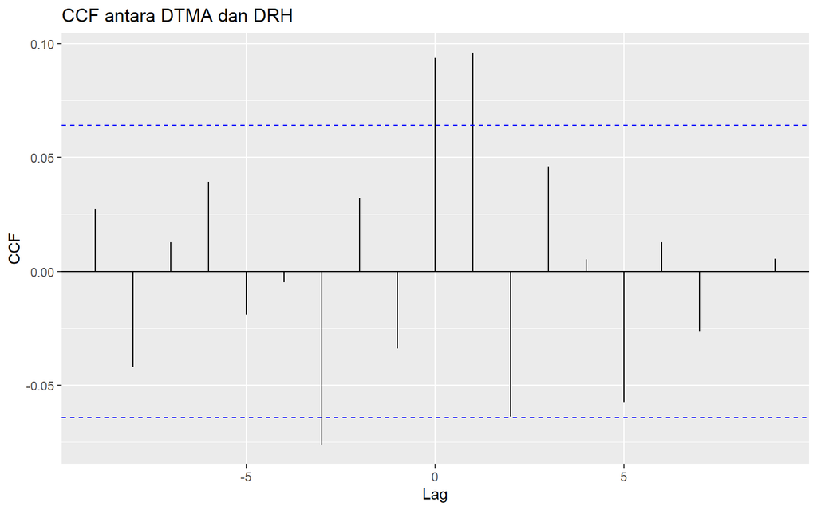

```r
ccf_result2 <- ggCcf(DTMA, DRH, lag.max=9, plot = TRUE)+ggtitle("CCF antara DTMA dan DRH")
ccf_result2
```

- Lag optimum q3 = 1

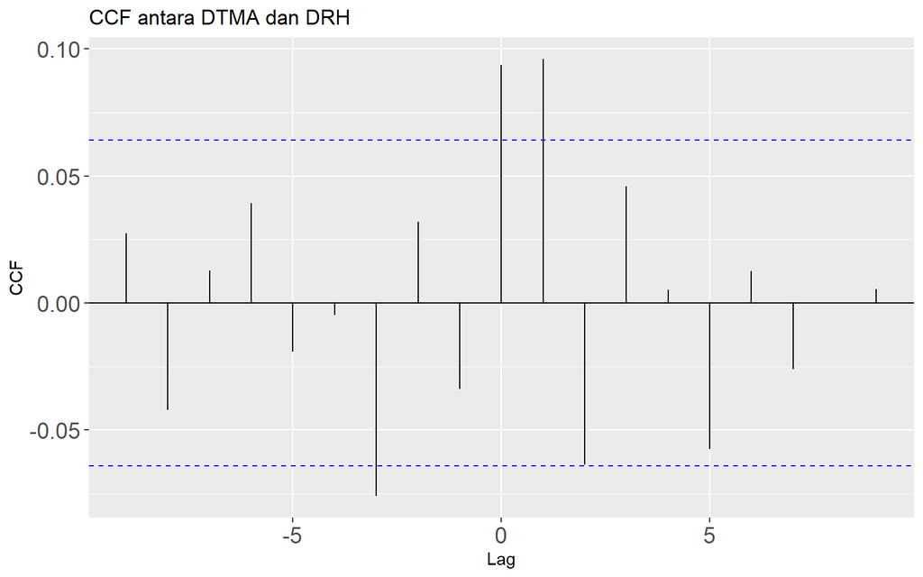

```r
ccf_result2 <- ggCcf(DTMA, DRH, lag.max = 9) +
  ggtitle("CCF antara DTMA dan DRH") +
  theme(
    axis.text.x = element_text(size = 14),  # Besarkan angka di sumbu X
    axis.text.y = element_text(size = 14)   # Besarkan angka di sumbu Y
  )

ccf_result2
```

### 6.5.3 Plot CCF Gabungan

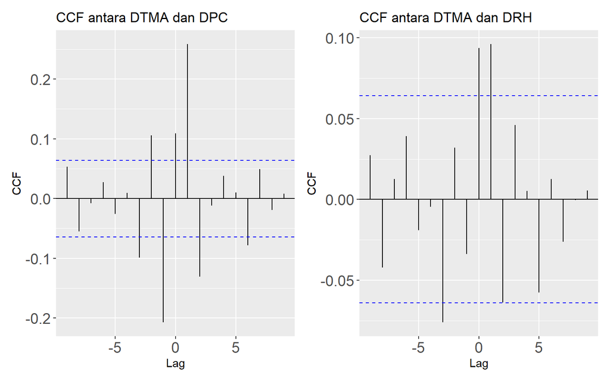

```r
# Menggabungkan plot dalam satu baris
combined_ccf <- ccf_result1 + ccf_result2

# Mencetak plot gabungan
print(combined_ccf)
```

- **DTMA dan DPC:** Korelasi silang paling kuat terdapat pada **lag 1 (positif)** dan **lag -1 (negatif)**. Beberapa lag lainnya juga menunjukkan korelasi yang signifikan.
- **DTMA dan DRH:** Korelasi silang paling kuat terdapat pada **lag 0 dan lag 1**, keduanya positif dan signifikan. Terdapat pula korelasi negatif signifikan pada **lag -3**.

Kedua peubah penjelas memiliki hubungan silang dengan DTMA pada beberapa lag, dengan **DRH menunjukkan hubungan positif yang jelas pada lag 0 dan 1**.

### 6.5.4 Nilai Korelasi CCF

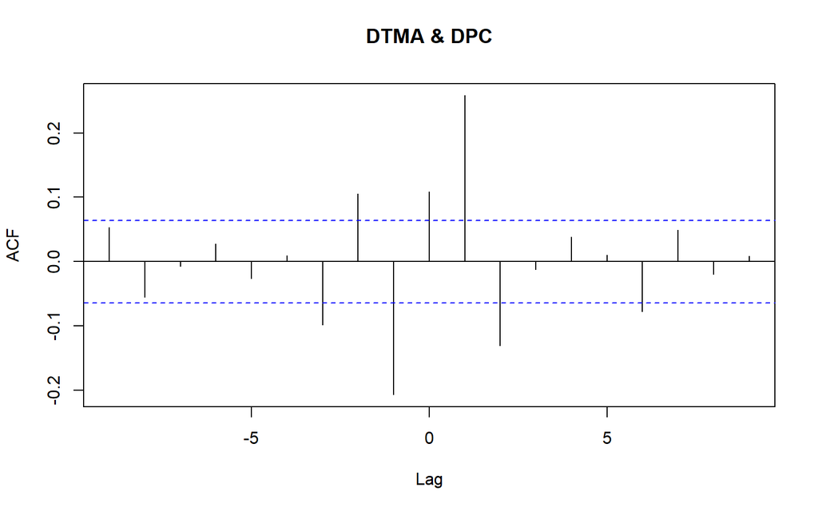

```r
ccf_result1 <- ccf(DTMA, DPC, lag.max=9, plot = TRUE)
```

```r
lags1 <- ccf_result1$lag
correlations1 <- ccf_result1$acf
```

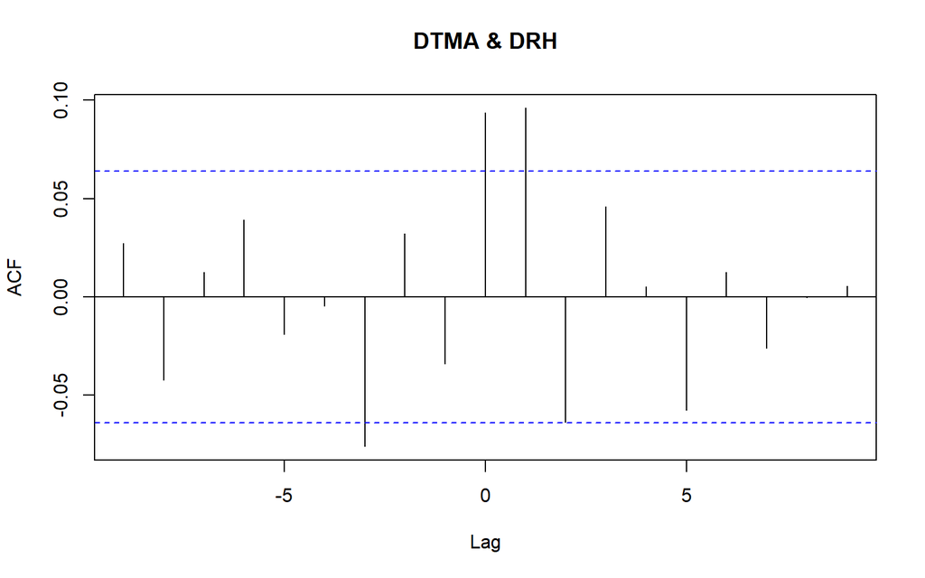

```r
ccf_result2 <- ccf(DTMA, DRH, lag.max=9, plot = TRUE)
```

```r
lags2 <- ccf_result2$lag
correlations2 <- ccf_result2$acf
```

```r
# Buat data frame untuk setiap CCF
ccf_df1 <- data.frame(Lag = lags1, Correlation = correlations1, Pair = "DTMA vs DPC")
ccf_df2 <- data.frame(Lag = lags2, Correlation = correlations2, Pair = "DTMA vs DRH")

# Gabungkan semua data frame menjadi satu
ccf_all_df <- rbind(ccf_df1, ccf_df2)
ccf_all_df
```

```
##    Lag   Correlation        Pair
## 1   -9  0.0529586274 DTMA vs DPC
## 2   -8 -0.0550552403 DTMA vs DPC
## 3   -7 -0.0075649185 DTMA vs DPC
## 4   -6  0.0272775490 DTMA vs DPC
## 5   -5 -0.0260687707 DTMA vs DPC
## 6   -4  0.0095200923 DTMA vs DPC
## 7   -3 -0.0985237382 DTMA vs DPC
## 8   -2  0.1056947588 DTMA vs DPC
## 9   -1 -0.2068571316 DTMA vs DPC
## 10   0  0.1086869199 DTMA vs DPC
## 11   1  0.2580985831 DTMA vs DPC
## 12   2 -0.1309036731 DTMA vs DPC
## 13   3 -0.0120556745 DTMA vs DPC
## 14   4  0.0379023799 DTMA vs DPC
```

[output cut: 24 more lines]

**CCF DTMA dan DPC**

Korelasi silang terbesar terdapat pada **lag 1 sebesar 0,2581**, menunjukkan hubungan positif antara DTMA dan DPC pada lag tersebut. Pada **lag -1** terdapat korelasi negatif sebesar **-0,2069**. Beberapa lag lainnya memiliki korelasi yang relatif kecil.

**CCF DTMA dan DRH**

Korelasi silang terbesar terdapat pada **lag 1 sebesar 0,0960**, diikuti **lag 0 sebesar 0,0936**, yang menunjukkan hubungan positif antara DTMA dan DRH pada kedua lag tersebut. Pada **lag -3** terdapat korelasi negatif sebesar **-0,0760**.

> Secara umum, hubungan silang DTMA dengan **DPC lebih kuat** dibandingkan dengan DRH, terutama pada **lag 1**.

# 7. **Dynardl (dynmac)**

## 7.1 Uji Kointegrasi

```r
modelbound <- ardlBound(data = train_2225 , formula = TMA ~ PC + RH, case = 2 , max.p = 1, max.q = 9)
```

```
##
## Orders being calculated with max.p = 1 and max.q = 9 ...
##
## Autoregressive order: 10 and p-orders: 2 1
## ------------------------------------------------------
##
##  Breusch-Godfrey Test for the autocorrelation in residuals:
##
##  Breusch-Godfrey test for serial correlation of order up to 1
##
## data:  modelFull$model
## LM test = 1.5157, df1 = 1, df2 = 909, p-value = 0.2186
##
## ------------------------------------------------------
##
##  Ljung-Box Test for the autocorrelation in residuals:
##
##  Box-Ljung test
##
## data:  res
## X-squared = 0.023902, df = 1, p-value = 0.8771
##
## ------------------------------------------------------
##
##  Breusch-Pagan Test for the homoskedasticity of residuals:
##
##  studentized Breusch-Pagan test
##
## data:  modelFull$model
## BP = 199.46, df = 15, p-value < 2.2e-16
##
## The p-value of Breusch-Pagan test for the homoskedasticity of residuals:  2.734809e-34 < 0.05!
## ------------------------------------------------------
##
##  Shapiro-Wilk test of normality of residuals:
##
##  Shapiro-Wilk normality test
##
## data:  modelFull$model$residual
## W = 0.88703, p-value < 2.2e-16
```

[output cut: 20 more lines]

```
##
##  ------------------------------------------------------
##  F-statistic note: Asymptotic critical values used.
##
## ------------------------------------------------------
##
##  Ramsey's RESET Test for model specification:
##
##  RESET test
##
## data:  modelECM$model
## RESET = 14.337, df1 = 1, df2 = 912, p-value = 0.0001628
##
## the p-value of RESET test:  0.0001628165 < 0.05!
## ------------------------------------------------------
```

```
## ------------------------------------------------------
## Error Correction Model Output:
##
## Time series regression with "ts" data:
## Start = 10, End = 935
##
## Call:
## dynlm(formula = as.formula(model.text), data = data)
##
## Residuals:
##      Min       1Q   Median       3Q      Max
## -130.086  -11.717   -2.635    6.745  136.100
##
## Coefficients:
##        Estimate Std. Error t value Pr(>|t|)
## ec.1   -0.17775    0.01577 -11.272  < 2e-16 ***
## dPC.t   0.67150    0.09149   7.340 4.73e-13 ***
## dPC.1   0.35361    0.09905   3.570 0.000376 ***
## dRH.t   0.71637    0.27437   2.611 0.009176 **
## dTMA.1 -0.42205    0.03010 -14.023  < 2e-16 ***
## dTMA.2 -0.27043    0.03320  -8.146 1.23e-15 ***
## dTMA.3 -0.19856    0.03398  -5.844 7.10e-09 ***
## dTMA.4 -0.12458    0.03440  -3.621 0.000309 ***
## dTMA.5 -0.14675    0.03396  -4.322 1.72e-05 ***
## dTMA.6 -0.12230    0.03394  -3.603 0.000332 ***
## dTMA.7 -0.09617    0.03356  -2.865 0.004262 **
## dTMA.8 -0.04125    0.03250  -1.269 0.204753
## dTMA.9  0.02274    0.02935   0.775 0.438574
## ---
## Signif. codes:  0 '***' 0.001 '**' 0.01 '*' 0.05 '.' 0.1 ' ' 1
##
## Residual standard error: 21.23 on 913 degrees of freedom
## Multiple R-squared:  0.3707, Adjusted R-squared:  0.3618
## F-statistic: 41.37 on 13 and 913 DF,  p-value: < 2.2e-16
##
## ------------------------------------------------------
## Long-run coefficients:
##      TMA.1       PC.1       RH.1
## -0.1777542  1.2022135  0.3960311
##
```

Nilai F-statistic sebesar 31.6584 lebih besar dari batas atas I(1) sebesar 5.00 pada taraf 1%, sehingga terdapat hubungan kointegrasi antara TMA, PC, dan RH.

## 7.2 Model

### 7.2.1 Jangka Pendek

```r
modelardl <- dynardl(
  DTMA ~ DPC + DRH,
  data = df,
  lags = list(
    "DTMA" = 1:9,
    "DPC" = 1,
    "DRH" = 1
  ),
  ec = TRUE
)
```

```
## [1] "Error correction (EC) specified; dependent variable to be run in differences."
```

```r
summary(modelardl)
```

```
##
## Call:
## lm(formula = as.formula(paste(paste(dvnamelist), "~", paste(colnames(IVs),
##     collapse = "+"), collapse = " ")))
##
## Residuals:
##     Min      1Q  Median      3Q     Max
## -82.905 -11.899  -3.051   7.310 140.121
##
## Coefficients:
##             Estimate Std. Error t value Pr(>|t|)
## (Intercept)  0.07954    0.75371   0.106 0.915980
## l.1.DTMA    -1.48549    0.03170 -46.861  < 2e-16 ***
## l.2.DTMA    -0.26216    0.03553  -7.378 3.60e-13 ***
## l.3.DTMA    -0.20926    0.03615  -5.788 9.76e-09 ***
## l.4.DTMA    -0.12204    0.03682  -3.315 0.000954 ***
## l.5.DTMA    -0.16120    0.03649  -4.418 1.12e-05 ***
## l.6.DTMA    -0.12655    0.03656  -3.461 0.000563 ***
## l.7.DTMA    -0.10256    0.03618  -2.835 0.004685 **
## l.8.DTMA    -0.05487    0.03493  -1.571 0.116531
## l.9.DTMA     0.02288    0.03169   0.722 0.470456
## l.1.DPC      0.72043    0.08740   8.243 5.79e-16 ***
## l.1.DRH      0.62171    0.29720   2.092 0.036725 *
## ---
## Signif. codes:  0 '***' 0.001 '**' 0.01 '*' 0.05 '.' 0.1 ' ' 1
##
## Residual standard error: 22.94 on 914 degrees of freedom
##   (9 observations deleted due to missingness)
## Multiple R-squared:  0.726,  Adjusted R-squared:  0.7227
## F-statistic: 220.1 on 11 and 914 DF,  p-value: < 2.2e-16
```

```r
AIC(modelardl$model)
```

```
## [1] 8443.511
```

Model jangka pendek menunjukkan bahwa **DPC berpengaruh positif dan signifikan terhadap DTMA** dengan koefisien 0.72043 (p-value < 0.05). **DRH juga berpengaruh positif dan signifikan terhadap DTMA** dengan koefisien 0.62171 (p-value = 0,0367). Selain itu, beberapa lag DTMA (lag 1–7) berpengaruh signifikan terhadap DTMA saat ini.

### 7.2.2 Jangka Panjang

```r
modelardll <- dynardl(
  formula = TMA ~ PC + RH,
  data = train_2225,
  levels = c("PC", "RH"),
  ec = FALSE,
)
```

```
## [1] "Dependent variable to be run in levels."
```

```r
summary(modelardll)
```

```
##
## Call:
## lm(formula = as.formula(paste(paste(dvnamelist), "~", paste(colnames(IVs),
##     collapse = "+"), collapse = " ")))
##
## Residuals:
##     Min      1Q  Median      3Q     Max
## -81.035 -12.390  -3.133   8.906 138.920
##
## Coefficients:
##             Estimate Std. Error t value Pr(>|t|)
## (Intercept) 99.84097   16.21708   6.157 1.10e-09 ***
## l.1.TMA      0.69406    0.02133  32.540  < 2e-16 ***
## PC           0.83239    0.09610   8.662  < 2e-16 ***
## RH           1.00643    0.19987   5.035 5.73e-07 ***
## ---
## Signif. codes:  0 '***' 0.001 '**' 0.01 '*' 0.05 '.' 0.1 ' ' 1
##
## Residual standard error: 23.34 on 931 degrees of freedom
##   (1 observation deleted due to missingness)
## Multiple R-squared:  0.6785, Adjusted R-squared:  0.6775
## F-statistic:   655 on 3 and 931 DF,  p-value: < 2.2e-16
```

```r
AIC(modelardll$model)
```

```
## [1] 8550.505
```

Dalam jangka panjang, **PC berpengaruh positif dan signifikan terhadap TMA** dengan koefisien 0.83239, sedangkan **RH berpengaruh positif dan signifikan terhadap TMA** dengan koefisien 1.00643. Keduanya memiliki p-value < 0.05, sehingga PC dan RH berpengaruh signifikan terhadap TMA dalam jangka panjang.

## 7.3 Uji Asumsi

### 7.3.1 Uji Autokorelasi Residual (Box-Ljung Test)

```r
res1 <- residuals(modelardl$model)
Box.test(res1, lag = 20, type = "Ljung-Box")
```

```
##
##  Box-Ljung test
##
## data:  res1
## X-squared = 19.038, df = 20, p-value = 0.5193
```

**Hipotesis:**

$$H_0 : Tidak \ ada \ autokorelasi \ dalam
\ residual \\ H_1 : Terdapat \ autokorelasi \ dalam \
residual$$

Kesimpulan: *p-value* = 0.5193 (>0.05) tak tolak $H_0$, tidak ada bukti signifikan autokorelasi dalam residual model.

### 7.3.2 Uji Normalitas (Jarque-Bera Test)

```r
jarque.bera.test(res1)
```

```
##
##  Jarque Bera Test
##
## data:  res1
## X-squared = 1281.6, df = 2, p-value < 2.2e-16
```

Hipotesis:

$$H_0 : Data \ residual \ berdistribusi \
normal \\ H_1 : Data \ residual \ tidak \ berdistribusi \
normal$$

Kesimpulan: p-value = $2.2e^{-16}$ (< 0.05). Tolak $H_0$, residual tidak berdistribusi normal.

### 7.3.3. Uji Heterokedastisitas (Breusch-Pagan Test)

```r
fitted_val1 <- fitted(modelardl$model)
bptest(res1 ~ fitted_val1)
```

```
##
##  studentized Breusch-Pagan test
##
## data:  res1 ~ fitted_val1
## BP = 1.3632, df = 1, p-value = 0.243
```

Hipotesis:

$$H_0 : Residual \ memiliki \ varians \
yang \ konstan \ (homoskedastis) \\ H_1 : Residual \ memiliki \ varians
\ yang \ tidak \ konstan \ (heterokedastis)$$

Kesimpulan: p-value = 0.243 (> 0.05), tak tolak $H_0$, residual memiliki varians yang konstan (homoskedastis).

### 7.3.4 Multikolinearitas

```r
vif(modelardl$model)
```

```
## l.1.DTMA l.2.DTMA l.3.DTMA l.4.DTMA l.5.DTMA l.6.DTMA l.7.DTMA l.8.DTMA
## 1.249782 1.570812 1.626521 1.687545 1.657613 1.664197 1.629196 1.518988
## l.9.DTMA  l.1.DPC  l.1.DRH
## 1.250541 1.153269 1.097102
```

- Lag DTMA: **1.25–1.69**
- Lag DPC: **1.15**
- Lag DRH: **1.10**

> Seluruh nilai VIF berada di bawah **10**, sehingga tidak terdapat indikasi **multikolinearitas** antarpeubah dalam model.

## 7. 4 Forecasting

### 7.4.1 Data Training

```r
# Differencing
DTMA <- diff(train_2225$TMA, differences = 1)
DPC  <- diff(train_2225$PC, differences = 1)
DRH  <- diff(train_2225$RH, differences = 1)

# Gabungkan menjadi data.frame
train_baru <- data.frame(DPC, DRH)
colnames(train_baru) <- c("DPC", "DRH")
```

```r
coefs <- summary(modelardl)$coefficients

intercept <- coefs["(Intercept)", "Estimate"]
b1 <- coefs["l.1.DPC", "Estimate"]
b2 <- coefs["l.1.DRH", "Estimate"]
```

```r
train_baru$DTMA_pred <- intercept +
  b1 * train_baru$DPC +
  b2 * train_baru$DRH
```

```r
# TMA ke-n = TMA ke-(n-1) + delta TMA ke-n
train_baru$TMA_pred <- NA
train_baru$TMA_pred[1] <- train_2225$TMA[1] + train_baru$DTMA_pred[1]

for(i in 2:nrow(train_baru)) {
  train_baru$TMA_pred[i] <- train_baru$TMA_pred[i-1] + train_baru$DTMA_pred[i]
}
```

```r
TMA_actual <- train_2225$TMA[-1]  # karena ada differencing
TMA_pred <- train_baru$TMA_pred
```

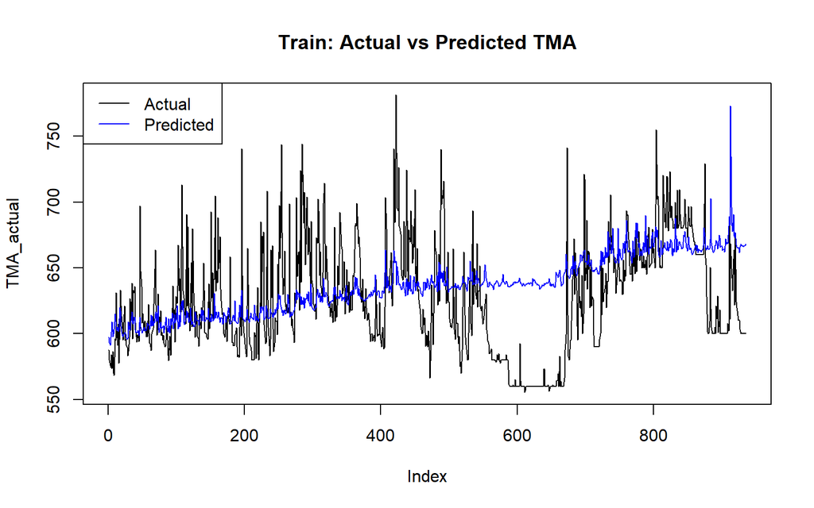

```r
plot(TMA_actual, type = "l", col = "black", main = "Train: Actual vs Predicted TMA")
lines(TMA_pred, col = "blue")
legend("topleft", legend = c("Actual", "Predicted"), col = c("black", "blue"), lty = 1)
```

```r
# Evaluasi
MAE <- mean(abs(TMA_pred - TMA_actual), na.rm = TRUE)
RMSE <- sqrt(mean((TMA_pred - TMA_actual)^2, na.rm = TRUE))
MAPE <- mean(abs((TMA_actual - TMA_pred) / TMA_actual), na.rm = TRUE) * 100

cat("MAE:", MAE, "\n")
```

```
## MAE: 31.66414
```

```r
cat("RMSE:", RMSE, "\n")
```

```
## RMSE: 41.07022
```

```r
cat("MAPE:", MAPE, "%\n")
```

```
## MAPE: 5.130371 %
```

Model menghasilkan MAPE sebesar 5.13%, yang menunjukkan tingkat kesalahan prediksi relatif rendah. Namun, secara visual prediksi belum mampu mengikuti seluruh fluktuasi dan lonjakan ekstrem pada data aktual.

### 7.4.2 Data Testing

```r
str(test_2225)
```

```
## tibble [160 × 7] (S3: tbl_df/tbl/data.frame)
##  $ Date    : Date[1:160], format: "2024-07-25" "2024-07-26" ...
##  $ TMA     : num [1:160] 600 600 600 600 600 ...
##  $ TM      : num [1:160] 24.4 24.9 24.9 24.7 24.5 ...
##  $ PC      : num [1:160] 0.01 0.01 0 0 0 ...
##  $ RH      : num [1:160] 85.3 84.4 82.3 82.3 81.6 ...
##  $ WS      : num [1:160] 1.32 1.13 1.24 1.01 1.16 1.35 1.25 1.01 0.98 0.99 ...
##  $ DataType: chr [1:160] "Test" "Test" "Test" "Test" ...
```

```r
summary(test_2225)
```

```
##       Date                 TMA              TM              PC
##  Min.   :2024-07-25   Min.   :590.0   Min.   :23.71   Min.   : 0.000
##  1st Qu.:2024-09-02   1st Qu.:599.6   1st Qu.:24.93   1st Qu.: 0.145
##  Median :2024-10-12   Median :618.2   Median :25.43   Median : 2.150
##  Mean   :2024-10-12   Mean   :620.5   Mean   :25.48   Mean   : 6.256
##  3rd Qu.:2024-11-21   3rd Qu.:640.0   3rd Qu.:26.03   3rd Qu.: 8.732
##  Max.   :2024-12-31   Max.   :744.0   Max.   :27.06   Max.   :74.460
##        RH              WS          DataType
##  Min.   :71.24   Min.   :0.660   Length:160
##  1st Qu.:80.47   1st Qu.:1.087   Class :character
##  Median :82.84   Median :1.270   Mode  :character
##  Mean   :83.08   Mean   :1.474
##  3rd Qu.:86.55   3rd Qu.:1.583
##  Max.   :93.96   Max.   :3.390
```

```r
TDPC <- diff(test_2225$PC, differences = 1)
TDRH <- diff(test_2225$RH, differences = 1)

test_baru <- data.frame(TDPC, TDRH)
```

```r
colnames(test_baru) <- c("DPC", "DRH")
```

```r
coefs <- summary(modelardl)$coefficients
coefs
```

```
##                Estimate Std. Error     t value      Pr(>|t|)
## (Intercept)  0.07953787 0.75371316   0.1055280  9.159800e-01
## l.1.DTMA    -1.48549061 0.03170006 -46.8608170 2.895372e-245
## l.2.DTMA    -0.26216448 0.03553161  -7.3783460  3.597338e-13
## l.3.DTMA    -0.20926129 0.03615189  -5.7883922  9.762272e-09
## l.4.DTMA    -0.12204373 0.03682087  -3.3145262  9.540847e-04
## l.5.DTMA    -0.16120030 0.03649032  -4.4176182  1.117423e-05
## l.6.DTMA    -0.12654844 0.03656265  -3.4611401  5.627992e-04
## l.7.DTMA    -0.10255553 0.03617559  -2.8349377  4.684534e-03
## l.8.DTMA    -0.05487372 0.03492939  -1.5709897  1.165311e-01
## l.9.DTMA     0.02288324 0.03169259   0.7220373  4.704562e-01
## l.1.DPC      0.72043361 0.08739820   8.2431169  5.793166e-16
## l.1.DRH      0.62171161 0.29720344   2.0918722  3.672540e-02
```

```r
intercept <- coefs["(Intercept)", "Estimate"]
b1 <- coefs["l.1.DPC", "Estimate"]
b2 <- coefs["l.1.DRH", "Estimate"]
```

```r
test_baru$DTMA_pred <- intercept +
  b1 * test_baru$DPC +
  b2 * test_baru$DRH
```

```r
last_TMA_train <- tail(train_2225$TMA, 1)
last_TMA_train
```

```
## [1] 600
```

```r
test_baru$TMA_pred <- NA
test_baru$TMA_pred[1] <- last_TMA_train + test_baru$DTMA_pred[1]

for(i in 2:nrow(test_baru)) {
  test_baru$TMA_pred[i] <- test_baru$TMA_pred[i-1] + test_baru$DTMA_pred[i]
}
```

```r
TMA_actual <- test_2225$TMA[-1]  # karena differencing
TMA_pred <- test_baru$TMA_pred

mse <- mean((TMA_actual - TMA_pred)^2, na.rm = TRUE)
rmse <- sqrt(mse)
```

```r
date_seq <- seq.Date(from = as.Date("2024-07-25"), by = "day", length.out = length(TMA_pred))
```

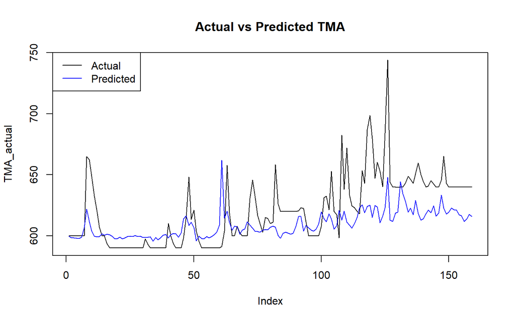

```r
plot(TMA_actual, type = "l", col = "black", main = "Actual vs Predicted TMA")
lines(TMA_pred, col = "blue")
legend("topleft", legend = c("Actual", "Predicted"), col = c("black", "blue"), lty = 1)
```

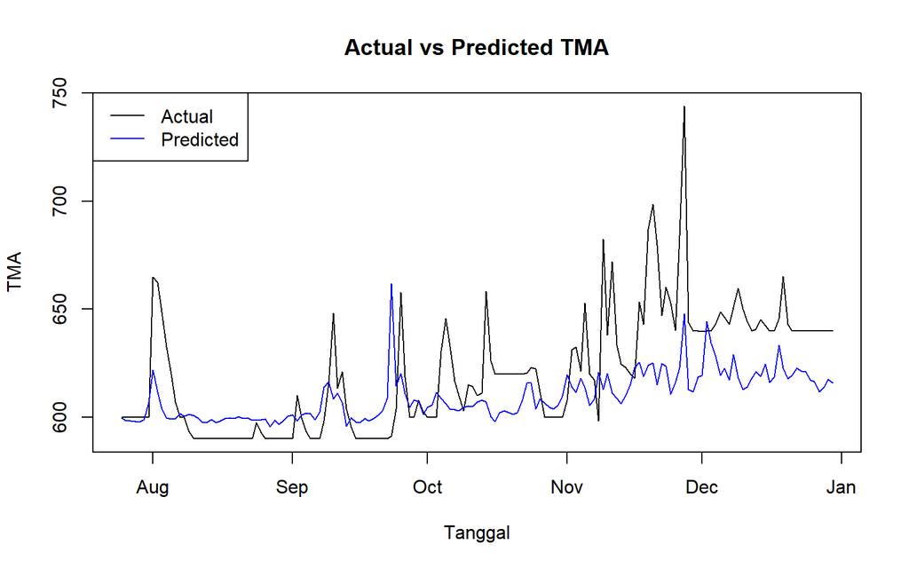

```r
plot(date_seq, TMA_actual, type = "l", col = "black",
     main = "Actual vs Predicted TMA", xlab = "Tanggal", ylab = "TMA")
lines(date_seq, TMA_pred, col = "blue")
legend("topleft", legend = c("Actual", "Predicted"),
       col = c("black", "blue"), lty = 1)
```

```r
# Asumsikan 'aktual_Y_test' adalah nilai Y aktual dari data testing
MAE <- mean(abs(TMA_pred - TMA_actual))
RMSE <- sqrt(mean((TMA_pred - TMA_actual)^2))
# Hitung MAPE jika nilai aktual Y tidak nol
MAPE <- mean(abs((TMA_actual - TMA_pred) / TMA_actual)) * 100

cat("MAE:", MAE, "\n")
```

```
## MAE: 18.02884
```

```r
cat("RMSE:", RMSE, "\n")
```

```
## RMSE: 24.49108
```

```r
cat("MAPE:", MAPE, "%\n")
```

```
## MAPE: 2.819428 %
```

Pada data testing, model menghasilkan MAE sebesar 18.03, RMSE sebesar 24.49, dan MAPE sebesar 2.82%. Hal ini menunjukkan bahwa model memiliki tingkat kesalahan prediksi yang relatif rendah pada data testing, meskipun beberapa lonjakan ekstrem pada TMA belum dapat ditangkap dengan baik.

```r
data_prediksi_15 <- read_excel("Data_Jan22_Mar25.xlsx")
data_prediksi_15 <- tail(data_prediksi_15, 120)
data_prediksi_15$Date <- as.Date(data_prediksi_15$Date)
str(data_prediksi_15)
```

```
## tibble [120 × 6] (S3: tbl_df/tbl/data.frame)
##  $ Date: Date[1:120], format: "2024-12-02" "2024-12-03" ...
##  $ TMA : num [1:120] 640 640 640 643 649 ...
##  $ TM  : num [1:120] 25.3 24.3 24.5 24.6 24.7 ...
##  $ PC  : num [1:120] 9.49 39.93 26.98 16.88 8.38 ...
##  $ RH  : num [1:120] 88.7 93.6 92.3 94 89.7 ...
##  $ WS  : num [1:120] 2.51 3.33 2.7 2.82 2.43 1.73 1.29 1.51 3.3 3.31 ...
```

```r
DPC_15 <- diff(data_prediksi_15$PC, differences = 1)
DRH_15 <- diff(data_prediksi_15$RH, differences = 1)

test_15 <- data.frame(DPC = DPC_15,DRH = DRH_15)
```

```r
colnames(test_15) <- c("DPC", "DRH")
```

```r
coefs <- summary(modelardl)$coefficients
coefs
```

```
##                Estimate Std. Error     t value      Pr(>|t|)
## (Intercept)  0.07953787 0.75371316   0.1055280  9.159800e-01
## l.1.DTMA    -1.48549061 0.03170006 -46.8608170 2.895372e-245
## l.2.DTMA    -0.26216448 0.03553161  -7.3783460  3.597338e-13
## l.3.DTMA    -0.20926129 0.03615189  -5.7883922  9.762272e-09
## l.4.DTMA    -0.12204373 0.03682087  -3.3145262  9.540847e-04
## l.5.DTMA    -0.16120030 0.03649032  -4.4176182  1.117423e-05
## l.6.DTMA    -0.12654844 0.03656265  -3.4611401  5.627992e-04
## l.7.DTMA    -0.10255553 0.03617559  -2.8349377  4.684534e-03
## l.8.DTMA    -0.05487372 0.03492939  -1.5709897  1.165311e-01
## l.9.DTMA     0.02288324 0.03169259   0.7220373  4.704562e-01
## l.1.DPC      0.72043361 0.08739820   8.2431169  5.793166e-16
## l.1.DRH      0.62171161 0.29720344   2.0918722  3.672540e-02
```

```r
intercept <- coefs["(Intercept)", "Estimate"]
b1 <- coefs["l.1.DPC", "Estimate"]
b2 <- coefs["l.1.DRH", "Estimate"]
```

```r
test_15$DTMA_pred <- intercept +
  b1 * test_15$DPC +
  b2 * test_15$DRH
```

```r
test_15$TMA_pred <- NA
test_15$TMA_pred[1] <- data_prediksi_15$TMA[1] + test_15$DTMA_pred[1]

for(i in 2:nrow(test_15)) {
  test_15$TMA_pred[i] <- test_15$TMA_pred[i-1] + test_15$DTMA_pred[i]
}
```

```r
tanggal_prediksi <- seq.Date(from = as.Date("2025-01-01"), by = "day", length.out = nrow(test_15))
```

```r
hasil_prediksi <- data.frame(
  date = tanggal_prediksi,
  TMA_actual = data_prediksi_15$TMA[-1],  # karena differencing
  TMA_pred = test_15$TMA_pred
)
hasil_prediksi
```

```
##           date TMA_actual TMA_pred
## 1   2025-01-01   640.0000 664.6455
## 2   2025-01-02   640.0000 654.6183
## 3   2025-01-03   643.3333 648.4348
## 4   2025-01-04   648.7500 639.7608
## 5   2025-01-05   646.2500 642.9276
## 6   2025-01-06   642.9167 637.4998
## 7   2025-01-07   650.8333 649.2231
## 8   2025-01-08   659.5833 638.6730
## 9   2025-01-09   650.0000 633.0167
## 10  2025-01-10   644.5833 634.2722
## 11  2025-01-11   640.0000 638.3911
## 12  2025-01-12   640.8333 641.2473
## 13  2025-01-13   645.0000 639.0258
## 14  2025-01-14   642.5000 645.0161
```

[output cut: 105 more lines]

```r
# Tentukan nama file Excel
nama_file_excel4 <- "hasil_peramalan.xlsx"

# Tulis data frame ke file Excel
write_xlsx(hasil_prediksi, path = nama_file_excel4)
```

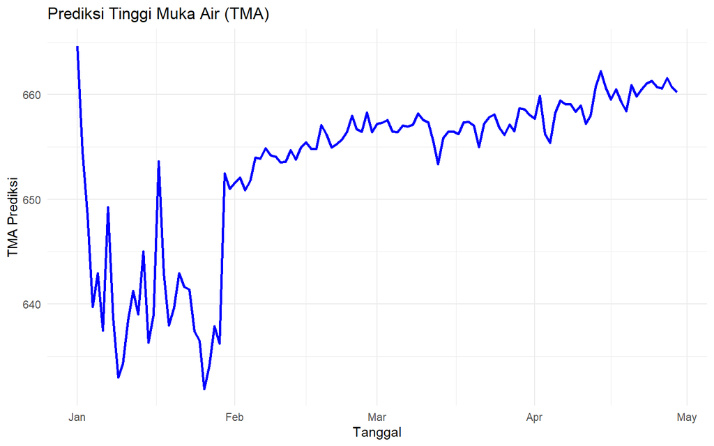

```r
ggplot(hasil_prediksi, aes(x = date, y = TMA_pred)) +
  geom_line(color = "blue", linewidth = 1) +
  labs(
    title = "Prediksi Tinggi Muka Air (TMA)",
    x = "Tanggal",
    y = "TMA Prediksi"
  ) +
  theme_minimal()
```

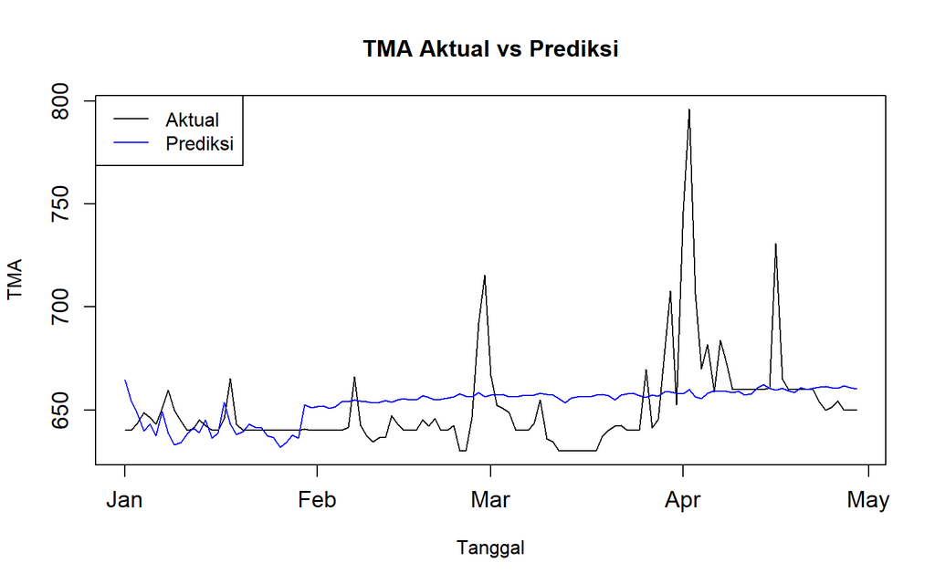

```r
plot(hasil_prediksi$date, hasil_prediksi$TMA_actual, type = "l", col = "black",
     ylab = "TMA", xlab = "Tanggal", main = "TMA Aktual vs Prediksi", cex.axis = 1.2)
lines(hasil_prediksi$date, hasil_prediksi$TMA_pred, col = "blue")
legend("topleft", legend = c("Aktual", "Prediksi"), col = c("black", "blue"), lty = 1)
```

```r
MAE <- mean(abs(hasil_prediksi$TMA_actual - hasil_prediksi$TMA_pred))
RMSE <- sqrt(mean((hasil_prediksi$TMA_actual - hasil_prediksi$TMA_pred)^2))
MAPE <- mean(abs((hasil_prediksi$TMA_actual - hasil_prediksi$TMA_pred) / hasil_prediksi$TMA_actual)) * 100

cat("MAE:", MAE, "\n")
```

```
## MAE: 14.68539
```

```r
cat("RMSE:", RMSE, "\n")
```

```
## RMSE: 22.83314
```

```r
cat("MAPE:", MAPE, "%\n")
```

```
## MAPE: 2.197515 %
```

Hasil peramalan menunjukkan bahwa nilai prediksi cenderung berada pada kisaran 650–660 dan cukup mengikuti nilai aktual pada periode dengan fluktuasi rendah. Namun, model belum mampu menangkap beberapa lonjakan ekstrem pada TMA. Meskipun demikian, diperoleh MAE sebesar 14.69, RMSE sebesar 22.83, dan MAPE sebesar 2.20%, yang menunjukkan tingkat kesalahan prediksi relatif rendah.